# Penguins Love RMarkdown

Carina

November 03, 2020

The YAML header in the .Rmd file specifies how your document will be outputted. I like to use `html` so that I can have a floating table of contents, and if you want to be able to caption figures and reference them in the text and/or if you want numbered sections then use `bookdown::html_document2`.

There’s an invisible setup chunk here where I specify global options for all chunks going forward. If I’m making analysis reports to share I’ll usually set `echo = FALSE` so that my code isn’t cluttering up the document, and for chunks where neither the code nor the output needs to be shown I’ll set `include = FALSE` in those individual chunk options.

For this doc though, I’ll leave `echo = TRUE` so you can see both the code and the output.

# 1 Set up

Load packages first. I’ve named the below chunk `packages` (even though you can’t see that name in the output html file) to make it easier to refer to when I’m editing the .Rmd file.

```r
# install.packages("palmerpenguins")
library(palmerpenguins)
library(magrittr)
library(tidyverse)
```

The `magrittr` package is super handy for the `%<>%` pipe. Notice how I can put text in backticks to make them look like code in the output document.

Let’s take a look at the first 6 rows (or the “head”) of our penguins dataset:

```r
head(penguins)
```

```
## # A tibble: 6 x 8
##   species island bill_length_mm bill_depth_mm flipper_length_… body_mass_g sex
##   <fct>   <fct>           <dbl>         <dbl>            <int>       <int> <fct>
## 1 Adelie  Torge…           39.1          18.7              181        3750 male
## 2 Adelie  Torge…           39.5          17.4              186        3800 fema…
## 3 Adelie  Torge…           40.3          18                195        3250 fema…
## 4 Adelie  Torge…           NA            NA                 NA          NA <NA>
## 5 Adelie  Torge…           36.7          19.3              193        3450 fema…
## 6 Adelie  Torge…           39.3          20.6              190        3650 male
## # … with 1 more variable: year <int>
```

We can also look at the structure of the dataset to get some info about the variables:

```r
str(penguins)
```

```
## tibble [344 × 8] (S3: tbl_df/tbl/data.frame)
##  $ species          : Factor w/ 3 levels "Adelie","Chinstrap",..: 1 1 1 1 1 1 1 1 1 1 ...
##  $ island           : Factor w/ 3 levels "Biscoe","Dream",..: 3 3 3 3 3 3 3 3 3 3 ...
##  $ bill_length_mm   : num [1:344] 39.1 39.5 40.3 NA 36.7 39.3 38.9 39.2 34.1 42 ...
##  $ bill_depth_mm    : num [1:344] 18.7 17.4 18 NA 19.3 20.6 17.8 19.6 18.1 20.2 ...
##  $ flipper_length_mm: int [1:344] 181 186 195 NA 193 190 181 195 193 190 ...
##  $ body_mass_g      : int [1:344] 3750 3800 3250 NA 3450 3650 3625 4675 3475 4250 ...
##  $ sex              : Factor w/ 2 levels "female","male": 2 1 1 NA 1 2 1 2 NA NA ...
##  $ year             : int [1:344] 2007 2007 2007 2007 2007 2007 2007 2007 2007 2007 ...
```

# 2 Do male and female penguins have different bill lengths?

We can do a *t*-test to answer this question.

```r
results = t.test(bill_length_mm ~ sex, data = penguins) %>%
  print()
```

```
##
##  Welch Two Sample t-test
##
## data:  bill_length_mm by sex
## t = -6.6725, df = 329.29, p-value = 1.066e-10
## alternative hypothesis: true difference in means is not equal to 0
## 95 percent confidence interval:
##  -4.865676 -2.649908
## sample estimates:
## mean in group female   mean in group male
##             42.09697             45.85476
```

I’ve saved the results as the variable `results` so that I can use them when writing up a results section:

There is a statistically significant difference between male and female penguins’ bill lengths, *t*(329.29) = -6.67, *p* < .001.

To add in-line R code (as opposed to code in chunks), place the code in backticks and put `r` at the start of your code.

## 2.1 Plot the results

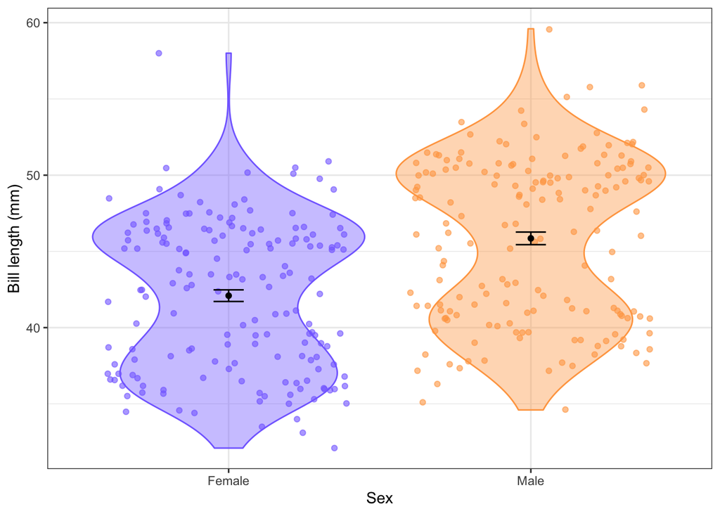

Figure 2.1: Difference in bill length between male and female penguins

```r
penguins %>%
  drop_na() %>%
  ggplot(aes(x = sex, y = bill_length_mm, colour = sex, fill = sex)) +
  geom_violin(alpha = .4) +
  geom_jitter(alpha = .6) +
  scale_colour_manual(values = c("slateblue1", "tan1")) +
  scale_fill_manual(values = c("slateblue1", "tan1")) +
  guides(colour = FALSE, fill = FALSE) +
  stat_summary(fun = mean, geom = "point", colour = "black") +
  stat_summary(fun.data = mean_se, geom = "errorbar", width = .1, colour = "black") +
  theme_bw() +
  labs(x = "Sex", y = "Bill length (mm)") +
  scale_x_discrete(labels = c("female" = "Female", "male" = "Male"))
```

Figure 2.1 indicates that female penguins have shorter bills than do males.

To be able to refer to the figure, the code chunk containing the figure code needs to have both a name and a caption.